```python
import pandas as pd
import numpy as np
import matplotlib.pyplot as plt

df = pd.read_csv('googleplaystore.csv')
df.head()
```

|  | App | Category | Rating | Reviews | Size | Installs | Type | Price | Content Rating | Genres | Last Updated | Current Ver | Android Ver |
| --- | --- | --- | --- | --- | --- | --- | --- | --- | --- | --- | --- | --- | --- |
| 0 | Photo Editor & Candy Camera & Grid & ScrapBook | ART_AND_DESIGN | 4.1 | 159 | 19M | 10,000+ | Free | 0 | Everyone | Art & Design | January 7, 2018 | 1.0.0 | 4.0.3 and up |
| 1 | Coloring book moana | ART_AND_DESIGN | 3.9 | 967 | 14M | 500,000+ | Free | 0 | Everyone | Art & Design;Pretend Play | January 15, 2018 | 2.0.0 | 4.0.3 and up |
| 2 | U Launcher Lite – FREE Live Cool Themes, Hide ... | ART_AND_DESIGN | 4.7 | 87510 | 8.7M | 5,000,000+ | Free | 0 | Everyone | Art & Design | August 1, 2018 | 1.2.4 | 4.0.3 and up |
| 3 | Sketch - Draw & Paint | ART_AND_DESIGN | 4.5 | 215644 | 25M | 50,000,000+ | Free | 0 | Teen | Art & Design | June 8, 2018 | Varies with device | 4.2 and up |
| 4 | Pixel Draw - Number Art Coloring Book | ART_AND_DESIGN | 4.3 | 967 | 2.8M | 100,000+ | Free | 0 | Everyone | Art & Design;Creativity | June 20, 2018 | 1.1 | 4.4 and up |

# Check for null value in data

```python
df.isnull().sum(axis=0)
```

```
App                  0
Category             0
Rating            1474
Reviews              0
Size                 0
Installs             0
Type                 1
Price                0
Content Rating       1
Genres               0
Last Updated         0
Current Ver          8
Android Ver          3
dtype: int64
```

Drop Records ith nulls in an of the columns

```python
print("Frame Size before: ",df.shape)
df.dropna(subset=['Rating','Type','Content Rating','Current Ver','Android Ver'],axis=0, inplace=True)
print("rame Size After: ",df.shape)
df.isnull().sum(axis=0)
```

```
Frame Size before:  (10841, 13)
rame Size After:  (9360, 13)
```

```
App               0
Category          0
Rating            0
Reviews           0
Size              0
Installs          0
Type              0
Price             0
Content Rating    0
Genres            0
Last Updated      0
Current Ver       0
Android Ver       0
dtype: int64
```

Extract the numerical value from the column ,multiply the value by 1000 if size is mentioned in MB

```python
j=df.columns.get_loc('Size')
for i in range(0,len(df)):
    if df.iloc[i,j].lower().endswith('k'):
        df.iloc[i,j]=float(df.iloc[i,j][0:-1])
    elif df.iloc[i,j].lower().endswith('m'):
        df.iloc[i,j]=float(df.iloc[i,j][0:-1])*1000
```

```python
df.Size = pd.to_numeric(df.Size,errors='coerce')
df.dropna(subset=['Size'],inplace=True)
df.shape
```

```
(7723, 13)
```

Rewiews is a numeric field that is loaded as string field . Convert it into numeric (int/float)

```python
df.Reviews =df.Reviews.astype('float64')
df.Reviews.dtypes
```

```
dtype('float64')
```

```python
df.Installs=df.Installs.str.replace(',','').str.replace('+','').astype('int64')
df.Installs.dtype
```

```
dtype('int64')
```

Price field is string andhas $ symbol. Remove $sign and convert it intpo umeric

```python
df.Price=df.Price.str.replace('$','').astype('float64')
```

```python
df.Price.dtype
```

```
dtype('float64')
```

# Sanity Check:

Average rating shoiuld be between 1 and 5 as onl these values are allowed on the pla store. Drop the rows that have a value outside this range

```python
filter=(df.Rating<1) | (df.Rating>5)
print("Data Frame size :",df.shape,"count of rows containing WRONG Rating:",filter.value_counts())
```

```
Data Frame size : (7723, 13) count of rows containing WRONG Rating: False    7723
Name: Rating, dtype: int64
```

Reviews should not be more than installs as only those who installed can review the app. If there are any such records, drop them.

```python
rows=df[df.Installs < df.Reviews].index
df.drop(rows,axis=0,inplace=True)
df.shape
```

```
(7717, 13)
```

```python
rows=df[(df.Type.str.lower()=='free' )& (df.Price > 0)].index
rows
```

```
Int64Index([], dtype='int64')
```

For free apps (tpes="free"), the price should not be >0. Drop Any such rows

```python
rows=df[(df.Type.str.lower()=='free')& (df.Price >0)].index
rows
```

```
Int64Index([], dtype='int64')
```

Boxplot for Price

```python
import seaborn as sns
```

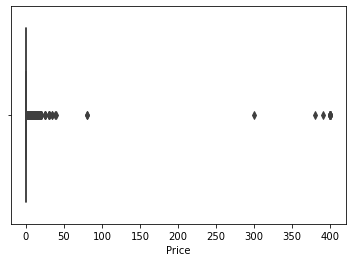

```python
sns.boxplot(df.Price)
```

Boxplot For reviews

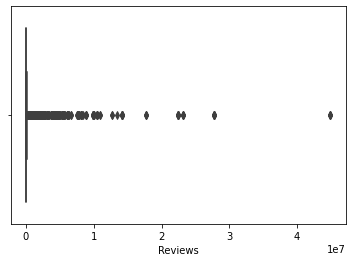

```python
sns.boxplot(x='Reviews',data=df)
```

Histogram For rating

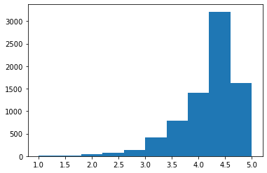

```python
plt.hist(df.Rating)
```

Histogram For size

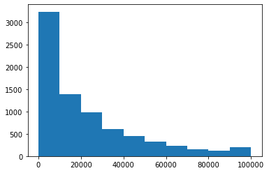

```python
plt.hist(df.Size)
```